# Assignment 0

# Isaac Ehrlich, 1004502102

```
# We will use unit testing to make sure our solutions are what we expect
# This shows how to import the Test package, which provides convenient functions like @test
using Test
# Setting a Random Seed is good practice so our code is consistent between runs
using Random # Import Random Package
Random.seed!(414); #Set Random Seed
# ; suppresses output, makes the writeup slightly cleaner.
# ! is a julia convention to indicate the function mutates a global state.
```

# Probability

## Variance and Covariance

Let $X$ and $Y$ be two continuous, independent random variables.

1. [3pts] Starting from the definition of independence, show that the independence of $X$ and $Y$ implies that their covariance is $0$.

Answer: If $X$ and $Y$ are independent, then $p(XY) = p(X)p(Y)$. This implies that $E(XY) = E(X)E(Y)$. The definition of covariance states that $Cov(X,Y) = E(XY) - E(X)E(Y)$. Plugging in the equation above leads to $Cov(X,Y) = E(X)E(Y) - E(X)-E(Y)$ $\therefore Cov(X,Y) = 0$ if $X$ and $Y$ are independent.

1. [3pts] For a scalar constant $a$, show the following two properties starting from the definition of expectation:

$$ \begin{align} \mathbb{E}(X+aY) &= \mathbb{E}(X) + a\mathbb{E}(Y)\\ \text{var}(X + aY) &= \text{var}(X) + a^2 \text{var}(Y) \end{align} $$

Answer:

$$\mathbb{E}(X+aY) = \int\int(X + aY)dxdy$$$$= \int Xdx + \int aYdy$$$$= \mathbb{E}(X) + a\int Ydy$$$$= \mathbb{E}(X) + a\mathbb{E}(Y)$$$$\text{var}(X + aY) = \text{var}(X) + \text{var}(aY) + 2(\mathbb{E}(XaY) - \mu_x\mu_y)$$$$= \text{var}(X) + \text{var}(aY) + 2(\mathbb{E}(X)\mathbb{E}(aY) - \mu_x\mu_y)$$$$= \text{var}(X) + \text{var}(aY)$$$$= \text{var}(X) + \mathbb{E}(aY - \mathbb(aY))^2$$$$= \text{var}(X) + \mathbb{E}(aY - a\mu)^2$$$$= \text{var}(X) + \mathbb{E}(a^2Y^2 - 2a^2\mu Y + a^2\mu^2)$$$$= \text{var}(X) + a^2E(Y^2) - a^2\mu^2$$$$= \text{var}(X) + a^2\text{var}(Y)$$

## 1D Gaussian Densities

1. [1pts] Can a probability density function (pdf) ever take values greater than $1$?

   Answer: Yes. For example, the pdf of the uniform function bounded between 0 and 0.5 will have values of 2. However, although the pdf can take values greater than 1, the integral of the pdf cannot.
1. Let $X$ be a univariate random variable distributed according to a Gaussian distribution with mean $\mu$ and variance $\sigma^2$.
   - [[1pts]] Write the expression for the pdf:

   Answer:

$$ X \sim \mathcal{N}(\mu, \sigma^2) P(x) = \frac{1}{\sigma\sqrt{2\pi}}e^{-\frac{(x-\mu)^2}{2\sigma^2}} $$

- [[2pts]] Write the code for the function that computes the pdf at $x$ with default values $\mu=0$ and $\sigma = \sqrt{0.01}$:

  Answer:

```
function gaussian_pdf(x; mean=0., variance=0.01)
  return exp(-0.5((x-mean)/sqrt(variance))^2)/(sqrt(variance * 2 * pi))
end
```

Test your implementation against a standard implementation from a library:

```
# Test answers
using Distributions: pdf, Normal # Note Normal uses N(mean, stddev) for parameters
using Test
@testset "Implementation of Gaussian pdf" begin
  x = randn()
  @test gaussian_pdf(x) ≈ pdf.(Normal(0.,sqrt(0.01)),x)
  # ≈ is syntax sugar for isapprox, typed with `\approx <TAB>`
  # or use the full function, like below
  @test isapprox(gaussian_pdf(x,mean=10., variance=1) , pdf.(Normal(10., sqrt(1)),x))
end;
```

Test Output:

Test.DefaultTestSet  
description → "Implementation of Gaussian pdf"  
results → Vector{Any} with 0 elements  
n_passed → 2  
anynonpass → false

1. [1pts] What is the value of the pdf at $x=0$? What is probability that $x=0$ (hint: is this the same as the pdf? Briefly explain your answer.)

Answer: gaussian_pdf(0) = 3.989422804014327

The value of the pdf at $x = 0$ is 3.989422804014327. However, for a continuous variable, the probability at any specific point (and not a range), is 0, since the integral of a point is 0.

1. A Gaussian with mean $\mu$ and variance $\sigma^2$ can be written as a simple transformation of the standard Gaussian with mean $0.$ and variance $1.$.
   - [[1pts]] Write the transformation that takes $x \sim \mathcal{N}(0.,1.)$ to $z \sim \mathcal{N}(\mu, \sigma^2)$:

     Answer: If $ Z ~ \sim \mathcal{N}(\mu, \sigma^2)$, $Z = \frac{x - \mu}/{\sigma}$
   - [[2pts]] Write a code implementation to produce $n$ independent samples from $\mathcal{N}(\mu, \sigma^2)$ by transforming $n$ samples from $\mathcal{N}(0.,1.)$.

     Answer

```
function sample_gaussian(n; mean=0., variance=0.01)
  # n samples from standard gaussia
  x = Normal(mean, variance)
  x_sample = rand(x, n)

  z = (x_sample.-mean)./variance
  return z
end;
```

[2pts] Test your implementation by computing statistics on the samples:

```
using Statistics: mean, var
@testset "Numerically testing Gaussian Sample Statistics" begin
  #TODO: Sample 100000 samples with your function and use mean and var to
  # compute statistics.
  # tests should compare statistics against the true mean and variance from arguments.
  # hint: use isapprox with keyword argument atol=1e-2
  sample = sample_gaussian(100000)
  @test isapprox(mean(sample), 0, atol=1e-2)
  @test isapprox(var(sample), 1, atol=1e-2)

end;
```

Test Results:  
Test.DefaultTestSet  
description → "Numerically testing Gaussian Sample Statistics"  
results → Vector{Any} with 0 elements  
n_passed → 2  
anynonpass → false

1. [3pts] Sample $10000$ samples from a Gaussian with mean $10.$ an variance $2$. Plot the **normalized** `histogram` of these samples. On the same axes `plot!` the pdf of this distribution. Confirm that the histogram approximates the pdf. (Note: with `Plots.jl` the function `plot!` will add to the existing axes.) sample = sample_gaussian(10000, mean=10, variance=2)

```
using Plots
using StatsPlots

histogram(sample,
  title = "Histogram and PDF of 10000 Standardized Normal Samples",
  ylabel = "Count", legend = false, normalize = true)
plot!(Normal(0,1), lw=5, legend = false)
```

##### Note: Histogram displayed at the bottom of HTML document

# Calculus

## Manual Differentiation

Let $x,y \in \mathbb{R}^m$, $A \in \mathbb{R}^{m \times n}$, and square matrix $B \in \mathbb{R}^{m \times m}$. And where $x'$ is the transpose of $x$. Answer the following questions in vector notation.

1. [1pts] What is the gradient of $x'y$ with respect to $x$?

Answer: $y$

1. [1pts] What is the gradient of $x'x$ with respect to $x$?

Answer: $2x$

1. [2pts] What is the Jacobian of $x'A$ with respect to $x$?

Answer: $x'A$

1. [2pts] What is the gradient of $x'Bx$ with respect to $x$?

Answer: $2Bx$

## Automatic Differentiation (AD)

Use one of the accepted AD library (Zygote.jl (julia), JAX (python), PyTorch (python)) to implement and test your answers above.

### [1pts] Create Toy Data

```
# Choose dimensions of toy data
m = 3
n = 4

# Make random toy data with correct dimensions
x = rand(3)
y = rand(3)
A = rand(3, 4)
B = rand(3, 3)
```

[1pts] Test to confirm that the sizes of your data is what you expect:

```
# Make sure your toy data is the size you expect!
@testset "Sizes of Toy Data" begin
  @test(size(x) == (3,))
  @test(size(y) == (3,))
  @test(size(A) == (3,4))
  @test(size(B) == (3,3))
end;
```

Test Results: description → "Sizes of Toy Data" results → Vector{Any} with 0 elements n_passed → 4 anynonpass → false

### Automatic Differentiation

1. [1pts] Compute the gradient of $f_1(x) = x'y$ with respect to $x$?

```
# Use AD Tool
using Zygote: gradient
# note: `Zygote.gradient` returns a tuple of gradients, one for each argument.
# if you want just the first element you will need to index into the tuple with [1]

f1(x) =(y*transpose(x))[1]
df1dx = gradient(x -> f1(x), x)
```

Output: 0.8954276470265778 0.00 0.00

1. [1pts] Compute the gradient of $f_2(x) = x'x$ with respect to $x$?

```
f2(x) = (x*transpose(x))[1]
df2dx = gradient(x -> f2(x), x)
```

Output: 1.9752946150783313 0.00 0.00

1. [1pts] Compute the Jacobian of $f_3(x) = x'A$ with respect to $x$?

If you try the usual `gradient` fucntion to compute the whole Jacobian it would give an error. You can use the following code to compute the Jacobian instead.

```
function jacobian(f, x)
    y = f(x)
    n = length(y)
    m = length(x)
    T = eltype(y)
    j = Array{T, 2}(undef, n, m)
    for i in 1:n
        j[i, :] .= gradient(x -> f(x)[i], x)[1]
    end
    return j
end
```

[2pts] Briefly, explain why `gradient` of $f_3$ is not well defined (hint: what is the dimensionality of the output?) and what the `jacobian` function is doing in terms of calls to `gradient`. Specifically, how many calls of `gradient` is required to compute a whole `jacobian` for $f : \mathbb{R}^m \rightarrow \mathbb{R}^n$?

The very important takeaway here is that, with AD, `gradient`s are cheap but full `jacobian`s are expensive.

```
f3(x) = (A * transpose(x))
df3dx = jacobian(f3, transpose(x) * A)
```

1. [1pts] Compute the gradient of $f_4(x) = x'Bx$ with respect to $x$?

```
f4(x) = (B*x*transpose(x))[1]
df4dx = gradient(x -> f4(x), x)
```

Output: 0.635503575329844 0.7449340969482323 0.06872091160695887

1. [2pts] Test all your implementations against the manually derived derivatives in previous question

[output not shown]

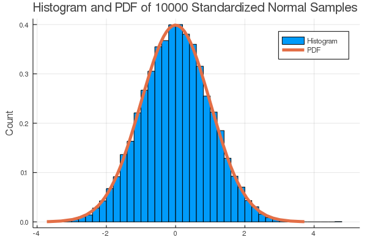

```python
from IPython.display import Image
Image(filename = "my_distributions.png")
```